# 1 INTRODUCTION TO MACHINE LEARNING

## 1.1 Machine Learning

### Machine Learning

#### What is the Learning Problem?

**Learning** $\equiv$ Improving with experience at some task

- Improve over task $T$,
- with respect to performance measure $P$,
- based on experience $E$.

> “A computer program is said to learn from experience $E$ with respect to some class of tasks $T$ and performance measure $P$, if its performance at tasks in $T$, as measured by $P$, improves with experience $E$.” – *Tom Mitchell*

[figure not shown]

#### Inductive Learning

- **Induction**: Generalizing from specific examples to general rules (Machine Learning).
- **Deduction**: Deriving specific conclusions from general premises (Traditional Logic).

[figure not shown]

#### Machine Learning vs. Traditional Programming

- **Traditional Programming**: You provide the **Data** and the **Rules** (Program). The computer outputs the **Answers**.
- **Machine Learning**: You provide the **Data** and the **Answers** (Labels). The computer outputs the **Rules** (Model).

[figure not shown]

#### Machine Learning vs. Artificial Intelligence

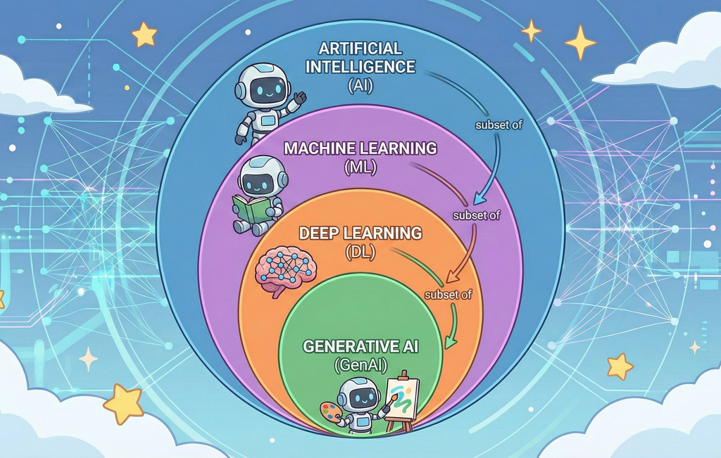

### Interpretable Machine Learning

#### Explainable Artificial Intelligence (XAI)

As models (like Deep Neural Networks) become more complex/accurate, they often become less interpretable (“Black Box”).

- **Interpretability**: The degree to which a human can understand the cause of a decision.
- **Explainability**: Techniques to explain the predictions of black-box models.

**Goals of XAI:**

1. **Trust**: Why did the model make this decision?
2. **Safety**: Will it fail in edge cases?
3. **Ethics**: Is the decision biased or discriminatory?

[figure not shown]

#### Human-AI Interaction

Effective collaboration requires mutual understanding:

1. **System’s Model of User**: The AI needs to understand human intent and context.
2. **User’s Model of System**: The human needs a mental model of how the AI works to use it effectively.

[figure not shown]

## 1.2 Learning Agent

#### Why Agents Need Learning

[figure not shown]

1. **Unknown Environments**: Designers cannot anticipate every possible state or interaction.
2. **Changing Environments**: The world changes over time; fixed programs fail.
3. **Efficiency**: It is often easier to let an agent “learn” a complex task (like walking or recognizing faces) from data than to manually code the rules.

#### Forms of Learning

How an agent learns depends on four factors:

1. **Component**: Which part of the agent is improving? (e.g., world model, policy, utility).
2. **Prior Knowledge**: What does the agent already know?
3. **Representation**: How are data and functions represented? (Linear weights, Neural Networks, etc.).
4. **Feedback**: What signal is used to learn?

[figure not shown]

#### Components that can be Learned

Virtually any part of an intelligent agent can be learned:

1. **Atomic Components**: Mapping states directly to actions.
2. **World Models**: Predicting the next state given current state and action (Transition Model).
3. **Utility Functions**: Learning how desirable a state is.
4. **Action-Value Functions**: Learning the expected future reward of an action (Q-values).
5. **Goals**: Inferring high-level objectives.

#### Types of Feedback (Learning Paradigms)

The type of feedback dictates the learning algorithm:

- **Supervised Learning**: The agent observes **Input-Output pairs** (Teacher gives the correct answer).
  - *Task*: Learn a function $f(x) \to y$.
  - *Example*: Image Classification, Spam Detection.
- **Unsupervised Learning**: The agent observes **Patterns** in data without labels.
  - *Task*: Find structure in input $x$.
  - *Example*: Clustering, Dimensionality Reduction.
- **Reinforcement Learning**: The agent learns from **Rewards/Punishments**.
  - *Task*: Learn a policy to maximize long-term reward.
  - *Example*: Playing Chess, Robot Navigation.
- **Semi-Supervised Learning**: A mix of a small amount of labeled data and a large amount of unlabeled data.

#### Machine Learning Workflow

A systematic approach to building ML systems:

1. **Data Collection**: Gather raw data (the fuel for ML).
2. **Data Preparation**: Clean, normalize, and transform data. Handle missing values.

   **Exploratory Data Analysis (EDA)**: Visualize data to understand distributions and correlations.
3. **Model Building**: Select algorithms and train models on the training set.
4. **Evaluation**: Test the model on unseen data (validation/test sets) to measure performance.
5. **Deployment**: Integrate the model into the production environment.
6. **Monitoring**: Continuously track performance to detect “drift” and retrain when necessary.

[figure not shown]

## 1.3 Data

#### Types of Data

- **Record**
  - Relational records
  - Data matrix: numerical matrix
  - Document data: text documents
  - Transaction data
- **Graph and network**
  - World Wide Web
  - Social or information networks
  - Molecular Structures
- **Ordered**
  - Video data: sequence of images
  - Temporal data: time-series
  - Sequential Data: transaction sequences
  - Genetic sequence data
- **Spatial, image and multimedia**
  - Spatial data: maps
  - Image data
  - Video data

#### Data Sets

- **Data sets** are made up of data objects.
- **A data object** represents an **entity** (also called samples, examples, instances, data points, objects, tuples).
- Data objects are described by **attributes**.

#### Attributes

**An attribute** (also called dimension, feature, variable) is a data field, representing a characteristic or feature of a data object.

| **Data set** | **Attributes** |
| --- | --- |
| Sales database | customers, store items, sales |
| Medical database | patients, treatments |
| University database | students, professors, courses |

#### Attribute Types

- **Nominal**: categories, states, or “names of things”
  - hair color = {auburn, black, blond, brown, grey, red, white}
  - marital status, occupation, ID numbers, zip codes
- **Binary**: nominal attribute with only two states
  - gender (symmetric: both outcomes equally important)
  - medical test (positive vs. negative) (asymmetric: outcomes not equally important)
- **Ordinal**: values have a meaningful order but magnitude between successive values is not known.
  - size = {small, medium, large}
  - grades, rankings

#### Numeric Attribute Types

- Quantity (integer or real-valued)
- **Interval scale**: Measured on a scale of equal-sized units. No true zero-point. Values have order
  - temperature in Celsius or Fahrenheit
  - calendar dates
- **Ratio scale**: Inherent zero-point
  - temperature in Kelvin
  - length
  - counts
  - monetary quantities

#### Discrete vs. Continuous Attributes

- **Discrete Attribute**: Has only a finite or countably infinite set of values
  - zip codes
  - profession

  **Note**: Sometimes, represented as integer variables; binary attributes are a special case of discrete attributes
- **Continuous Attribute**: Has real numbers as attribute values
  - temperature
  - height, or weight

#### Sample datasets

- Housing data for 506 census tracts of Boston from the 1970 census

[figure not shown]

- Iris data set gives the measurements in centimeters of the variables sepal length and width and petal length and width, respectively, for 50 flowers from each of 3 species of iris.

[figure not shown]

- BBC news dataset

  | **#** | **sentences** | **class** |
  | --- | --- | --- |
  | 0 | Labour plans maternity pay rise\n\nMaternity p... | politics |
  | 1 | Watchdog probes e-mail deletions\n\nThe inform... | politics |
  | 2 | Hewitt decries ‘career sexism’\n\nPlans to ext... | politics |
  | 3 | Labour chooses Manchester\n\nThe Labour Party ... | politics |
  | 4 | Brown ally rejects Budget spree\n\nChancellor ... | politics |
  | ... | ... | ... |
  | 2220 | Trial begins of Spain’s top banker\n\nThe tria... | business |
  | 2221 | UK economy ends year with spurt\n\nThe UK econ... | business |
  | 2222 | HealthSouth ex-boss goes on trial\n\nThe forme... | business |
  | 2223 | Euro firms miss out on optimism\n\nMore than 9... | business |
  | 2224 | Lacroix label bought by US firm\n\nLuxury good... | business |

#### Large Language Models

| Year | Model | # parameters | dataset size |
| --- | --- | --- | --- |
| 2018 | ELMo | $9.36*10^{7}$ | $\approx$ 6GB * |
| 2019 | BERT | $3.4*10^{8}$ | 16 GB |
| 2019 | Megatron-LM | $8.3*10^{9}$ | 174 GB |
| 2020 | **GPT-3** | $1.75*10^{11}$ | 570 GB |
| 2020 | GShard | $6.00*10^{11}$ | $\dagger$ |
| 2021 | Switch-C | $1.57*10^{12}$ | 745 GB |
| 2021 | Gopher | $2.8*10^{11}$ | $\approx$ 1800 GB $\ddagger$ |
| 2022 | PaLM | $5.4*10^{11}$ | $\approx$ 4680 GB $\$ |

1 billion words

**$\dagger$**

25 billion training examples (100 languages)

**$\ddagger$**

300 billion tokens

**$\$**

780 billion tokens

#### How Much Data is that?

Someone who reads a 400 page book each day will take how long to read the same amount of information as GPT-3 was trained on?

1. 2 years
2. 20 years
3. 200 years
4. > 2000 years

#### Tensor-based Attributes

A **tensor** is a generalized matrix, a finite table of numerical values indexed along several discrete dimensions.

- A 0d tensor is a scalar
- A 1d tensor is a vector (e.g. a sound sample)
- A 2d tensor is a matrix (e.g. a grayscale image)
- A 3d tensor (e.g. a multi-channel image)
- A 4d tensor (e.g. a sequence of multi-channel images)

[figure not shown]

#### Sample dataset

- $28\times28$ grayscale images, 60k train samples, 10k test samples.

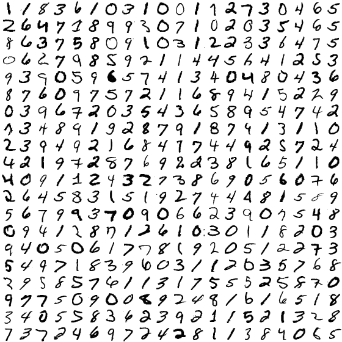

## 1.4 Exploration

#### Data Visualization

**Visualization** is the conversion of data into a **visual** or **tabular format** so that the characteristics of the data and the relationships among data items or attributes can be analyzed or reported.

Humans have a well developed ability to analyze large amounts of information that is presented visually

- Can detect general patterns and trends
- Can detect outliers and unusual patterns

[figure not shown]

## 1.5 Type of Learnings

#### Basic Premise of Learning

“**Using a set of observations to uncover an underlying process or rule**”

broad premise $\Longrightarrow$ many variations

- Supervised learning
- Unsupervised learning
- Reinforcement learning

#### Supervised Learning

- We get data $\mathcal{D}$: (**input**, **correct ouput**)
  - When the **output** is one of *a finite set of values*, the learning problem is called **classification**
  - When the **output** is a *number*, the learning problem is called **regression**
- Example from vending machine - **coin classification**

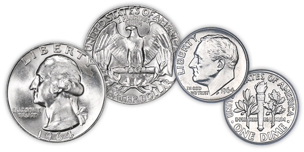

[figure not shown]

#### Unsupervised Learning

- Instead of (**input**, **correct output**), we get (**input**, ?)

[figure not shown]

#### Reinforcement Learning

- We get data $\mathcal{D}$: (**observation**, **action**, and **reward**)

[figure not shown]

## 1.6 Successes of Machine Learning

### Vision

#### Detection and Segmentation

- **Object Detection**: State-of-the-art models like YOLO (You Only Look Once) and EfficientDet can detect objects in real-time with high accuracy.
- **Segmentation**: The Segment Anything Model (SAM) from Meta (2023) can “cut out” any object in any image with a single click, demonstrating zero-shot generalization.

[figure not shown]

#### Face recognition

- Modern systems achieve near-perfect accuracy in unconstrained environments.
- Widely used in security, authentication (FaceID), and photo organization.

[figure not shown]

#### Generative Vision

- **Image Generation**: Models like **DALL-E 3**, **Midjourney**, and **Stable Diffusion** can generate photorealistic images from text descriptions.
- **Video Generation**: Models like **Sora** (OpenAI) and **Gen-3 Alpha** (Runway) are pushing boundaries in generating coherent video clips from text.

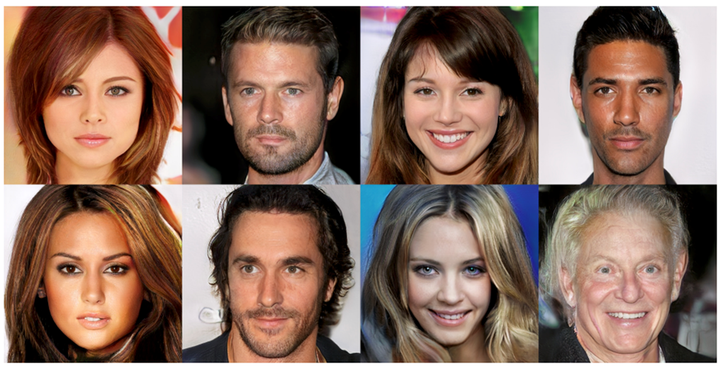

### Language

#### Large Language Models (LLMs) & Chatbots

- **ChatGPT (OpenAI)**: Based on GPT-4, it exhibits human-level performance on various professional and academic benchmarks.
- **Claude (Anthropic)**: Known for large context windows and strong reasoning capabilities.
- **Gemini (Google)**: A multimodal model capable of understanding and reasoning across text, images, audio, video, and code.

[figure not shown]

#### Translation

- **Real-time Translation**: Models like Meta’s **SeamlessM4T** enable nearly instantaneous speech-to-speech translation across nearly 100 languages.

> “The reason Boeing are doing this is to cram more seats in to make their plane more competitive with our products,” said Kevin Keniston, head of passenger comfort at Europe’s Airbus.

$\downarrow$

> Kevin Keniston, người đứng đầu bộ phận thoải mái của hành khách tại Europe’s Airbus, cho biết: “Lý do Boeing làm điều này là để nhồi nhét thêm ghế để máy bay của họ cạnh tranh hơn với các sản phẩm của chúng tôi.”

#### Code Generation

- **Coding Assistants**: Tools like **GitHub Copilot** and **Cursor**, powered by models like OpenAI’s Codex and GPT-4, assist developers by writing entire functions, debugging code, and translating between languages.

### Games

#### Strategic Gaming

- **AlphaGo (2016)**: Beat world champion Lee Sedol at Go.
- **AlphaStar (2019)**: Achieved Grandmaster level in StarCraft II.
- **Cicero (2022)**: Mastered the game of *Diplomacy*, combining strategic reasoning with natural language negotiation to cooperate with humans.

[figure not shown]

### Robotics

#### Embodied AI

- **Robotic Transformers (RT-2)**: Google’s vision-language-action (VLA) model that controls robots using web-scale data.
- **Humanoid Robots**: **Tesla Optimus** and **Boston Dynamics’ Atlas** are rapidly evolving to perform complex, dynamic tasks in human environments.

[figure not shown]

### Science

#### Accelerating Discovery

- **AlphaFold 3 (2024)**: Predicts the structure and interactions of all life’s molecules (proteins, DNA, RNA, ligands) with high accuracy.
- **GNoME (2023)**: Discovered 2.2 million new crystals, accelerating materials science by orders of magnitude.

[figure not shown]

## 1.7 References

[video not shown]